# EasyVisa Project

## Context:

Business communities in the United States are facing high demand for human resources, but one of the constant challenges is identifying and attracting the right talent, which is perhaps the most important element in remaining competitive. Companies in the United States look for hard-working, talented, and qualified individuals both locally as well as abroad.

The Immigration and Nationality Act (INA) of the US permits foreign workers to come to the United States to work on either a temporary or permanent basis. The act also protects US workers against adverse impacts on their wages or working conditions by ensuring US employers' compliance with statutory requirements when they hire foreign workers to fill workforce shortages. The immigration programs are administered by the Office of Foreign Labor Certification (OFLC).

OFLC processes job certification applications for employers seeking to bring foreign workers into the United States and grants certifications in those cases where employers can demonstrate that there are not sufficient US workers available to perform the work at wages that meet or exceed the wage paid for the occupation in the area of intended employment.

## Objective:

In FY 2016, the OFLC processed 775,979 employer applications for 1,699,957 positions for temporary and permanent labor certifications. This was a nine percent increase in the overall number of processed applications from the previous year. The process of reviewing every case is becoming a tedious task as the number of applicants is increasing every year.

The increasing number of applicants every year calls for a Machine Learning based solution that can help in shortlisting the candidates having higher chances of VISA approval. OFLC has hired your firm EasyVisa for data-driven solutions. You as a data scientist have to analyze the data provided and, with the help of a classification model:

- Facilitate the process of visa approvals.
- Recommend a suitable profile for the applicants for whom the visa should be certified or denied based on the drivers that significantly influence the case status.

## Data Description

The data contains the different attributes of the employee and the employer. The detailed data dictionary is given below.

- case_id: ID of each visa application
- continent: Information of continent the employee
- education_of_employee: Information of education of the employee
- has_job_experience: Does the employee has any job experience? Y= Yes; N = No
- requires_job_training: Does the employee require any job training? Y = Yes; N = No
- no_of_employees: Number of employees in the employer's company
- yr_of_estab: Year in which the employer's company was established
- region_of_employment: Information of foreign worker's intended region of employment in the US.
- prevailing_wage: Average wage paid to similarly employed workers in a specific occupation in the area of intended employment. The purpose of the prevailing wage is to ensure that the foreign worker is not underpaid compared to other workers offering the same or similar service in the same area of employment.
- unit_of_wage: Unit of prevailing wage. Values include Hourly, Weekly, Monthly, and Yearly.
- full_time_position: Is the position of work full-time? Y = Full Time Position; N = Part Time Position
- case_status: Flag indicating if the Visa was certified or denied

## Importing necessary libraries and data

```python
# to load and manipulate data
import pandas as pd
import numpy as np

# to visualize data
import matplotlib.pyplot as plt
import seaborn as sns

# to split data into training and test sets
from sklearn.model_selection import train_test_split

# to build decision tree model
from sklearn import tree
from sklearn.tree import DecisionTreeClassifier
from sklearn.ensemble import BaggingClassifier
from sklearn.ensemble import RandomForestClassifier
from sklearn.ensemble import AdaBoostClassifier
from sklearn.ensemble import GradientBoostingClassifier


# to tune different models
from sklearn.model_selection import GridSearchCV

# to compute classification metrics
from sklearn.metrics import (
    confusion_matrix,
    accuracy_score,
    recall_score,
    precision_score,
    make_scorer,
    f1_score,
)
import warnings
warnings.simplefilter(action='ignore', category=FutureWarning)
warnings.simplefilter(action='ignore', category=RuntimeWarning)
```

```python
# function to create labeled barplots


def labeled_barplot(data, feature, perc=False, n=None):
    """
    Barplot with percentage at the top

    data: dataframe
    feature: dataframe column
    perc: whether to display percentages instead of count (default is False)
    n: displays the top n category levels (default is None, i.e., display all levels)
    """

    total = len(data[feature])  # length of the column
    count = data[feature].nunique()
    if n is None:
        plt.figure(figsize=(count + 2, 6))
    else:
        plt.figure(figsize=(n + 2, 6))

    plt.xticks(rotation=90, fontsize=15)
    ax = sns.countplot(
        data=data,
        x=feature,
        palette="Paired",
        order=data[feature].value_counts().index[:n],
    )

    for p in ax.patches:
        if perc == True:
            label = "{:.1f}%".format(
                100 * p.get_height() / total
            )  # percentage of each class of the category
        else:
            label = p.get_height()  # count of each level of the category

        x = p.get_x() + p.get_width() / 2  # width of the plot
        y = p.get_height()  # height of the plot

        ax.annotate(
            label,
            (x, y),
            ha="center",
            va="center",
            size=12,
            xytext=(0, 5),
            textcoords="offset points",
        )  # annotate the percentage

    plt.show()  # show the plot
```

## Import Dataset

- Observations
- Sanity checks

```python
df = pd.read_csv("EasyVisa.csv")
data = df.copy()
```

## Overview of Dataset

```python
data.head()
```

|  | case_id | continent | education_of_employee | has_job_experience | requires_job_training | no_of_employees | yr_of_estab | region_of_employment | prevailing_wage | unit_of_wage | full_time_position | case_status |
| --- | --- | --- | --- | --- | --- | --- | --- | --- | --- | --- | --- | --- |
| 0 | EZYV01 | Asia | High School | N | N | 14513 | 2007 | West | 592.2029 | Hour | Y | Denied |
| 1 | EZYV02 | Asia | Master's | Y | N | 2412 | 2002 | Northeast | 83425.6500 | Year | Y | Certified |
| 2 | EZYV03 | Asia | Bachelor's | N | Y | 44444 | 2008 | West | 122996.8600 | Year | Y | Denied |
| 3 | EZYV04 | Asia | Bachelor's | N | N | 98 | 1897 | West | 83434.0300 | Year | Y | Denied |
| 4 | EZYV05 | Africa | Master's | Y | N | 1082 | 2005 | South | 149907.3900 | Year | Y | Certified |

```python
data.shape
```

```
(25480, 12)
```

- The dataset has 25480 rows and 12 columns.

```python
data.info()
```

```
<class 'pandas.core.frame.DataFrame'>
RangeIndex: 25480 entries, 0 to 25479
Data columns (total 12 columns):
 #   Column                 Non-Null Count  Dtype
---  ------                 --------------  -----
 0   case_id                25480 non-null  object
 1   continent              25480 non-null  object
 2   education_of_employee  25480 non-null  object
 3   has_job_experience     25480 non-null  object
 4   requires_job_training  25480 non-null  object
 5   no_of_employees        25480 non-null  int64
 6   yr_of_estab            25480 non-null  int64
 7   region_of_employment   25480 non-null  object
 8   prevailing_wage        25480 non-null  float64
 9   unit_of_wage           25480 non-null  object
 10  full_time_position     25480 non-null  object
 11  case_status            25480 non-null  object
dtypes: float64(1), int64(2), object(9)
memory usage: 2.3+ MB
```

```python
data.isnull().sum()
```

```
case_id                  0
continent                0
education_of_employee    0
has_job_experience       0
requires_job_training    0
no_of_employees          0
yr_of_estab              0
region_of_employment     0
prevailing_wage          0
unit_of_wage             0
full_time_position       0
case_status              0
dtype: int64
```

```python
data.describe().T
```

|  | count | mean | std | min | 25% | 50% | 75% | max |
| --- | --- | --- | --- | --- | --- | --- | --- | --- |
| no_of_employees | 25480.0 | 5667.043210 | 22877.928848 | -26.0000 | 1022.00 | 2109.00 | 3504.0000 | 602069.00 |
| yr_of_estab | 25480.0 | 1979.409929 | 42.366929 | 1800.0000 | 1976.00 | 1997.00 | 2005.0000 | 2016.00 |
| prevailing_wage | 25480.0 | 74455.814592 | 52815.942327 | 2.1367 | 34015.48 | 70308.21 | 107735.5125 | 319210.27 |

```python
data.duplicated().sum()
```

```
np.int64(0)
```

> - There are no null values, no duplicates

`converting "objects" to "category" reduces the data space required to store the dataframe`

```python
cols = data.select_dtypes(['object'])
cols.columns
```

```
Index(['case_id', 'continent', 'education_of_employee', 'has_job_experience',
       'requires_job_training', 'region_of_employment', 'unit_of_wage',
       'full_time_position', 'case_status'],
      dtype='object')
```

```python
# Decision tree in Python can take only numerical / categorical colums. It cannot take string / object types.
# The following code loops through each column and checks if the column type is object then converts those columns
# into categorical with each distinct value becoming a category or code.
for i in cols.columns:
    data[i] = data[i].astype('category')
```

```python
data.info()
```

```
<class 'pandas.core.frame.DataFrame'>
RangeIndex: 25480 entries, 0 to 25479
Data columns (total 12 columns):
 #   Column                 Non-Null Count  Dtype
---  ------                 --------------  -----
 0   case_id                25480 non-null  category
 1   continent              25480 non-null  category
 2   education_of_employee  25480 non-null  category
 3   has_job_experience     25480 non-null  category
 4   requires_job_training  25480 non-null  category
 5   no_of_employees        25480 non-null  int64
 6   yr_of_estab            25480 non-null  int64
 7   region_of_employment   25480 non-null  category
 8   prevailing_wage        25480 non-null  float64
 9   unit_of_wage           25480 non-null  category
 10  full_time_position     25480 non-null  category
 11  case_status            25480 non-null  category
dtypes: category(9), float64(1), int64(2)
memory usage: 2.0 MB
```

`we can see that the memory usage has decreased from 2.3+ MB to 2 MB`, this technique is generally useful for bigger datasets.

```python
data.describe().T
```

|  | count | mean | std | min | 25% | 50% | 75% | max |
| --- | --- | --- | --- | --- | --- | --- | --- | --- |
| no_of_employees | 25480.0 | 5667.043210 | 22877.928848 | -26.0000 | 1022.00 | 2109.00 | 3504.0000 | 602069.00 |
| yr_of_estab | 25480.0 | 1979.409929 | 42.366929 | 1800.0000 | 1976.00 | 1997.00 | 2005.0000 | 2016.00 |
| prevailing_wage | 25480.0 | 74455.814592 | 52815.942327 | 2.1367 | 34015.48 | 70308.21 | 107735.5125 | 319210.27 |

```python
data.describe(include='all').T
```

|  | count | unique | top | freq | mean | std | min | 25% | 50% | 75% | max |
| --- | --- | --- | --- | --- | --- | --- | --- | --- | --- | --- | --- |
| case_id | 25480 | 25480 | EZYV9999 | 1 | NaN | NaN | NaN | NaN | NaN | NaN | NaN |
| continent | 25480 | 6 | Asia | 16861 | NaN | NaN | NaN | NaN | NaN | NaN | NaN |
| education_of_employee | 25480 | 4 | Bachelor's | 10234 | NaN | NaN | NaN | NaN | NaN | NaN | NaN |
| has_job_experience | 25480 | 2 | Y | 14802 | NaN | NaN | NaN | NaN | NaN | NaN | NaN |
| requires_job_training | 25480 | 2 | N | 22525 | NaN | NaN | NaN | NaN | NaN | NaN | NaN |
| no_of_employees | 25480.0 | NaN | NaN | NaN | 5667.04321 | 22877.928848 | -26.0 | 1022.0 | 2109.0 | 3504.0 | 602069.0 |
| yr_of_estab | 25480.0 | NaN | NaN | NaN | 1979.409929 | 42.366929 | 1800.0 | 1976.0 | 1997.0 | 2005.0 | 2016.0 |
| region_of_employment | 25480 | 5 | Northeast | 7195 | NaN | NaN | NaN | NaN | NaN | NaN | NaN |
| prevailing_wage | 25480.0 | NaN | NaN | NaN | 74455.814592 | 52815.942327 | 2.1367 | 34015.48 | 70308.21 | 107735.5125 | 319210.27 |
| unit_of_wage | 25480 | 4 | Year | 22962 | NaN | NaN | NaN | NaN | NaN | NaN | NaN |
| full_time_position | 25480 | 2 | Y | 22773 | NaN | NaN | NaN | NaN | NaN | NaN | NaN |
| case_status | 25480 | 2 | Certified | 17018 | NaN | NaN | NaN | NaN | NaN | NaN | NaN |

- case id is regular id of application that will not play any role
- Application's from ASIA is 66% highest among other continents
- `Case_status is our target variable where 67% records are 'Certified'`
- Number of employees are ranging from negative 26 to 602069
- In the given dataset years of establishment is from 1800s to 2016
- Average wage paid to similarly employed workers is ranging from 2.13 to 319210

```python
data.drop(['case_id'],axis=1,inplace=True)
```

`Dropped case_id as it will nto add any information`

```python
data.info()
```

```
<class 'pandas.core.frame.DataFrame'>
RangeIndex: 25480 entries, 0 to 25479
Data columns (total 11 columns):
 #   Column                 Non-Null Count  Dtype
---  ------                 --------------  -----
 0   continent              25480 non-null  category
 1   education_of_employee  25480 non-null  category
 2   has_job_experience     25480 non-null  category
 3   requires_job_training  25480 non-null  category
 4   no_of_employees        25480 non-null  int64
 5   yr_of_estab            25480 non-null  int64
 6   region_of_employment   25480 non-null  category
 7   prevailing_wage        25480 non-null  float64
 8   unit_of_wage           25480 non-null  category
 9   full_time_position     25480 non-null  category
 10  case_status            25480 non-null  category
dtypes: category(8), float64(1), int64(2)
memory usage: 797.7 KB
```

**Let's look at the unique values of all the categories**

```python
cols_cat= data.select_dtypes(['category'])
for i in cols_cat.columns:
    print('Unique values in',i, 'are :')
    print(cols_cat[i].value_counts())
    print('*'*50)
    print('Unique values in',i, 'in %age are :')
    print(round(100*(cols_cat[i].value_counts()/25480),2))
    print('*'*50)
```

```
Unique values in continent are :
continent
Asia             16861
Europe            3732
North America     3292
South America      852
Africa             551
Oceania            192
Name: count, dtype: int64
Unique values in continent in %age are :
continent
Asia             66.17
Europe           14.65
North America    12.92
South America     3.34
Africa            2.16
Oceania           0.75
Name: count, dtype: float64
Unique values in education_of_employee are :
education_of_employee
Bachelor's     10234
Master's        9634
High School     3420
Doctorate       2192
Name: count, dtype: int64
Unique values in education_of_employee in %age are :
education_of_employee
Bachelor's     40.16
Master's       37.81
High School    13.42
Doctorate       8.60
Name: count, dtype: float64
Unique values in has_job_experience are :
has_job_experience
Y    14802
N    10678
Name: count, dtype: int64
Unique values in has_job_experience in %age are :
has_job_experience
Y    58.09
```

[output cut: 47 more lines]

```
Unique values in full_time_position in %age are :
full_time_position
Y    89.38
N    10.62
Name: count, dtype: float64
Unique values in case_status are :
case_status
Certified    17018
Denied        8462
Name: count, dtype: int64
Unique values in case_status in %age are :
case_status
Certified    66.79
Denied       33.21
Name: count, dtype: float64
```

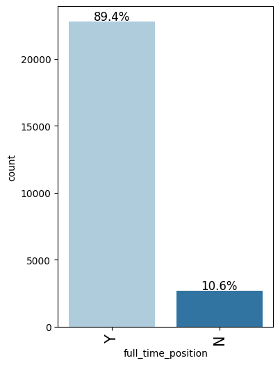

```python
labeled_barplot(data,'full_time_position',perc=True)
```

## Exploratory Data Analysis (EDA)

- EDA is an important part of any project involving data.
- It is important to investigate and understand the data better before building a model with it.
- A few questions have been mentioned below which will help you approach the analysis in the right manner and generate insights from the data.
- A thorough analysis of the data, in addition to the questions mentioned below, should be done.

```python
def histogram_boxplot(data, feature, figsize=(15, 10), kde=False, bins=None):
    """
    Boxplot and histogram combined

    data: dataframe
    feature: dataframe column
    figsize: size of figure (default (15,10))
    kde: whether to show the density curve (default False)
    bins: number of bins for histogram (default None)
    """
    f2, (ax_box2, ax_hist2) = plt.subplots(
        nrows=2,  # Number of rows of the subplot grid= 2
        sharex=True,  # x-axis will be shared among all subplots
        gridspec_kw={"height_ratios": (0.25, 0.75)},
        figsize=figsize,
    )  # creating the 2 subplots
    sns.boxplot(
        data=data, x=feature, ax=ax_box2, showmeans=True, color="violet"
    )  # boxplot will be created and a triangle will indicate the mean value of the column
    sns.histplot(
        data=data, x=feature, kde=kde, ax=ax_hist2, bins=bins
    ) if bins else sns.histplot(
        data=data, x=feature, kde=kde, ax=ax_hist2
    )  # For histogram
    ax_hist2.axvline(
        data[feature].mean(), color="green", linestyle="--"
    )  # Add mean to the histogram
    ax_hist2.axvline(
        data[feature].median(), color="black", linestyle="-"
    )  # Add median to the histogram
```

```python
# function to plot stacked bar chart


def stacked_barplot(data, predictor, target):
    """
    Print the category counts and plot a stacked bar chart

    data: dataframe
    predictor: independent variable
    target: target variable
    """
    count = data[predictor].nunique()
    sorter = data[target].value_counts().index[-1]
    tab1 = pd.crosstab(data[predictor], data[target], margins=True).sort_values(
        by=sorter, ascending=False
    )
    print(tab1)
    print("-" * 120)
    tab = pd.crosstab(data[predictor], data[target], normalize="index").sort_values(
        by=sorter, ascending=False
    )
    tab.plot(kind="bar", stacked=True, figsize=(count + 1, 5))
    plt.legend(
        loc="lower left",
        frameon=False,
    )
    plt.legend(loc="upper left", bbox_to_anchor=(1, 1))
    plt.show()
```

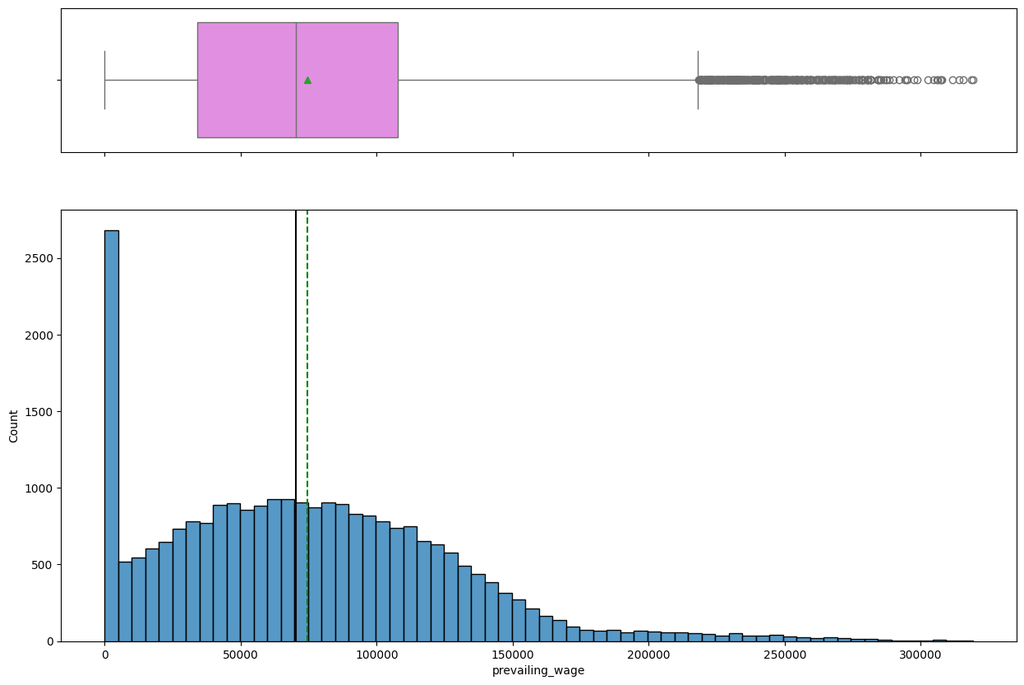

```python
histogram_boxplot(data,'prevailing_wage')
```

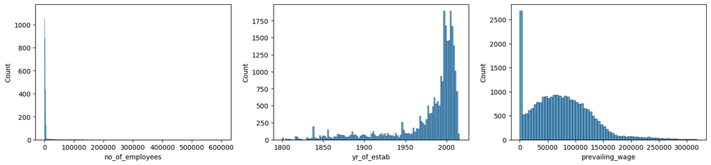

```python
# defining the figure size
plt.figure(figsize=(15, 10))

# defining the list of numerical features to plot
num_features = ['no_of_employees', 'yr_of_estab', 'prevailing_wage']

# plotting the histogram for each numerical feature
for i, feature in enumerate(num_features):
    plt.subplot(3, 3, i+1)    # assign a subplot in the main plot
    sns.histplot(data=data, x=feature)    # plot the histogram

plt.tight_layout();   # to add spacing between plots
```

- Year of establishment exhibits a left skewed distribution
- Prevailing wage, number of employees exhibits a right skewed distribution

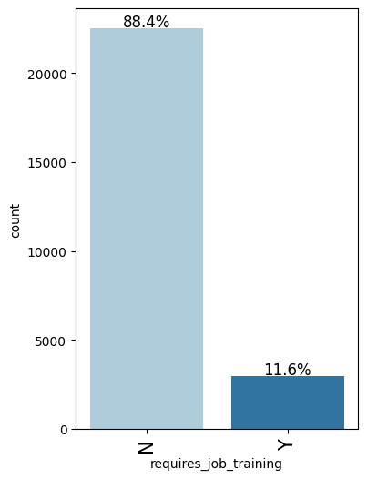

```python
labeled_barplot(data,'requires_job_training',perc=True)
```

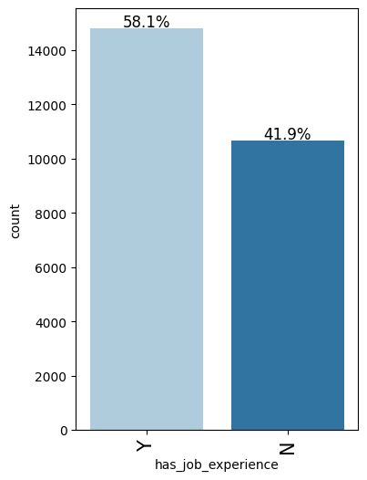

```python
labeled_barplot(data,'has_job_experience',perc=True)
```

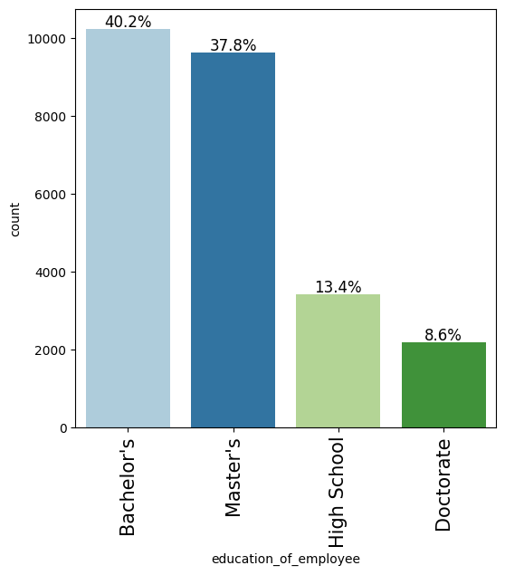

```python
labeled_barplot(data,'education_of_employee',perc=True)
```

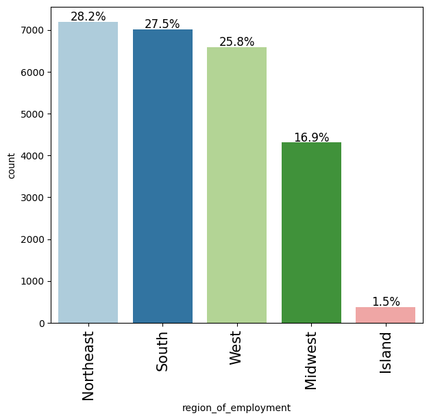

```python
labeled_barplot(data,'region_of_employment',perc=True)
```

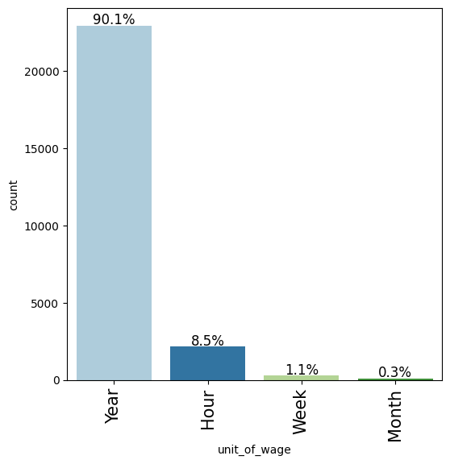

```python
labeled_barplot(data,'unit_of_wage',perc=True)
```

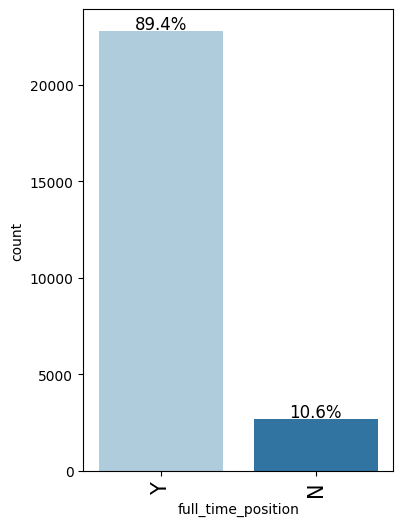

```python
labeled_barplot(data,'full_time_position',perc=True)
```

```
case_status         Certified  Denied    All
full_time_position
All                     17018    8462  25480
Y                       15163    7610  22773
N                        1855     852   2707
------------------------------------------------------------------------------------------------------------------------
```

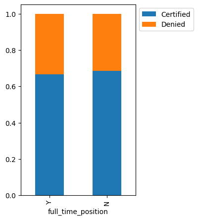

```python
stacked_barplot(data, "full_time_position", "case_status")
```

- The rate of full time position does not play any role in VISA certification

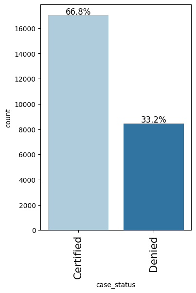

```python
labeled_barplot(data,'case_status',perc=True)
```

**Leading Questions**:

1. Those with higher education may want to travel abroad for a well-paid job. Does education play a role in Visa certification?
2. How does the visa status vary across different continents?
3. Experienced professionals might look abroad for opportunities to improve their lifestyles and career development. Does work experience influence visa status?
4. In the United States, employees are paid at different intervals. Which pay unit is most likely to be certified for a visa?
5. The US government has established a prevailing wage to protect local talent and foreign workers. How does the visa status change with the prevailing wage?

**Leading Questions**:

1. Those with higher education may want to travel abroad for a well-paid job. Does education play a role in Visa certification?

```
case_status            Certified  Denied    All
education_of_employee
All                        17018    8462  25480
Bachelor's                  6367    3867  10234
High School                 1164    2256   3420
Master's                    7575    2059   9634
Doctorate                   1912     280   2192
------------------------------------------------------------------------------------------------------------------------
```

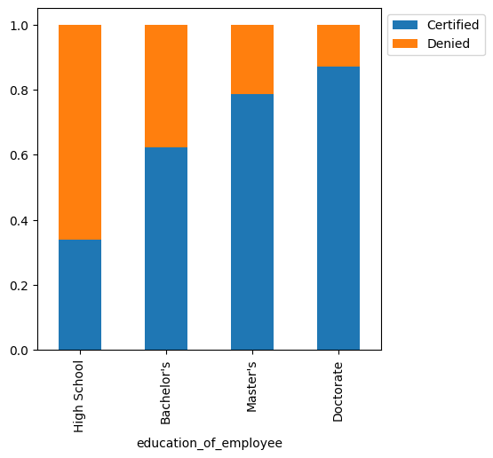

```python
stacked_barplot(data, "education_of_employee", "case_status")
```

- With higher the education status, higher the chances of getting VISA APPROVED
- Applicants with Docatorate degree has 87%, Master's degree is 78% acceptance rate
2. How does the visa status vary across different continents?

```
case_status    Certified  Denied    All
continent
All                17018    8462  25480
Asia               11012    5849  16861
North America       2037    1255   3292
Europe              2957     775   3732
South America        493     359    852
Africa               397     154    551
Oceania              122      70    192
------------------------------------------------------------------------------------------------------------------------
```

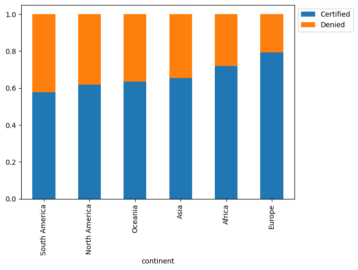

```python
stacked_barplot(data, "continent", "case_status")
```

- Applicants from Europe has highest %age of acceptance
- Most applicants are from Asia where acceptance rate is 65%
3. Experienced professionals might look abroad for opportunities to improve their lifestyles and career development. Does work experience influence visa status?

```
case_status         Certified  Denied    All
has_job_experience
All                     17018    8462  25480
N                        5994    4684  10678
Y                       11024    3778  14802
------------------------------------------------------------------------------------------------------------------------
```

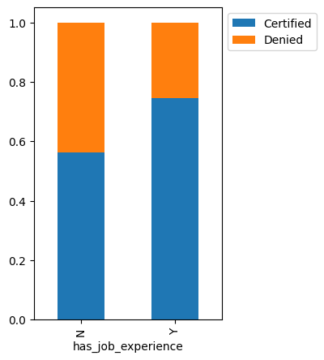

```python
stacked_barplot(data, "has_job_experience", "case_status")
```

- Yes, having a workexperience do play a role in VISA Staus as per the above plot applicants having prior expirince were Approved VISA with rate of ~75%
- Whereas without any experience have PASS rate of 57%
4. In the United States, employees are paid at different intervals. Which pay unit is most likely to be certified for a visa?

```
case_status   Certified  Denied    All
unit_of_wage
All               17018    8462  25480
Year              16047    6915  22962
Hour                747    1410   2157
Week                169     103    272
Month                55      34     89
------------------------------------------------------------------------------------------------------------------------
```

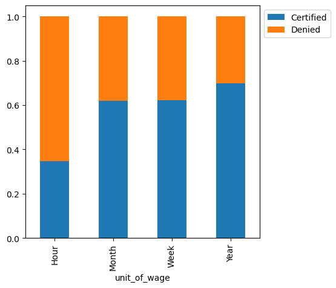

```python
stacked_barplot(data, "unit_of_wage", "case_status")
```

- Year has highest no. of Wage unit with highest rate of certified application
5. The US government has established a prevailing wage to protect local talent and foreign workers. How does the visa status change with the prevailing wage?

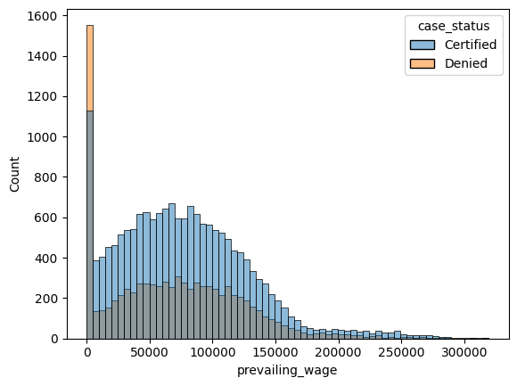

```python
sns.histplot(data=data, x='prevailing_wage', hue='case_status')
plt.show()
```

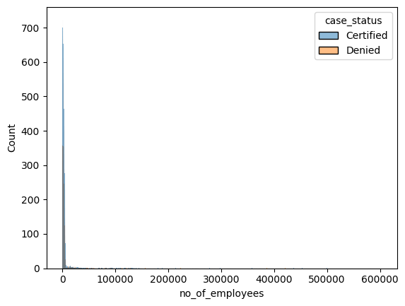

```python
sns.histplot(data=data, x='no_of_employees', hue='case_status')
plt.show()
```

## Data Preprocessing

- Missing value treatment (if needed)
- Feature engineering
- Outlier detection and treatment (if needed)
- Preparing data for modeling
- Any other preprocessing steps (if needed)

```python
data.isnull().sum()
```

```
continent                0
education_of_employee    0
has_job_experience       0
requires_job_training    0
no_of_employees          0
yr_of_estab              0
region_of_employment     0
prevailing_wage          0
unit_of_wage             0
full_time_position       0
case_status              0
dtype: int64
```

- there are no missing data

```python
data.duplicated().sum()
```

```
np.int64(0)
```

- in the data there are no duplicates
- there are no null values

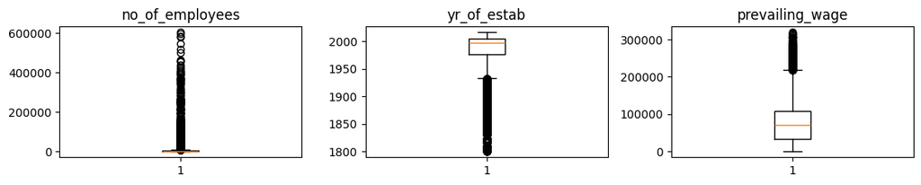

```python
# outlier detection using boxplot
numeric_columns = data.select_dtypes(include=np.number).columns.tolist()

plt.figure(figsize=(15, 12))

for i, variable in enumerate(numeric_columns):
    plt.subplot(6, 4, i + 1)
    plt.boxplot(data[variable], whis=1.5)
    plt.tight_layout()
    plt.title(variable)

plt.show()
```

```python
data['case_status']
```

```
0           Denied
1        Certified
2           Denied
3           Denied
4        Certified
           ...
25475    Certified
25476    Certified
25477    Certified
25478    Certified
25479    Certified
Name: case_status, Length: 25480, dtype: category
Categories (2, object): ['Certified', 'Denied']
```

```python
#modifying target variable 'ceritfied' to 1 else to 0
data['case_status'] = data['case_status'].apply(lambda x : 1 if x=='Certified' else 0)

X = data.drop(['case_status'],axis=1)
y = data['case_status']

X = pd.get_dummies(X,drop_first=True)
X.head()
```

|  | no_of_employees | yr_of_estab | prevailing_wage | continent_Asia | continent_Europe | continent_North America | continent_Oceania | continent_South America | education_of_employee_Doctorate | education_of_employee_High School | ... | has_job_experience_Y | requires_job_training_Y | region_of_employment_Midwest | region_of_employment_Northeast | region_of_employment_South | region_of_employment_West | unit_of_wage_Month | unit_of_wage_Week | unit_of_wage_Year | full_time_position_Y |
| --- | --- | --- | --- | --- | --- | --- | --- | --- | --- | --- | --- | --- | --- | --- | --- | --- | --- | --- | --- | --- | --- |
| 0 | 14513 | 2007 | 592.2029 | True | False | False | False | False | False | True | ... | False | False | False | False | False | True | False | False | False | True |
| 1 | 2412 | 2002 | 83425.6500 | True | False | False | False | False | False | False | ... | True | False | False | True | False | False | False | False | True | True |
| 2 | 44444 | 2008 | 122996.8600 | True | False | False | False | False | False | False | ... | False | True | False | False | False | True | False | False | True | True |
| 3 | 98 | 1897 | 83434.0300 | True | False | False | False | False | False | False | ... | False | False | False | False | False | True | False | False | True | True |
| 4 | 1082 | 2005 | 149907.3900 | False | False | False | False | False | False | False | ... | True | False | False | False | True | False | False | False | True | True |

5 rows × 21 columns

```python
# Splitting data into training and test set:
X_train, X_test, y_train, y_test =train_test_split(X, y, test_size=0.3, random_state=1,stratify=y)
print(X_train.shape, X_test.shape)
```

```
(17836, 21) (7644, 21)
```

```python
print("Shape of training set:", X_train.shape)
print("Shape of test set:", X_test.shape, '\n')
print("Percentage of classes in training set:")
print(100*y_train.value_counts(normalize=True), '\n')
print("Percentage of classes in test set:")
print(100*y_test.value_counts(normalize=True))
```

```
Shape of training set: (17836, 21)
Shape of test set: (7644, 21)

Percentage of classes in training set:
case_status
1    66.791882
0    33.208118
Name: proportion, dtype: float64

Percentage of classes in test set:
case_status
1    66.784406
0    33.215594
Name: proportion, dtype: float64
```

```python
y.value_counts(1)
```

```
case_status
1    0.667896
0    0.332104
Name: proportion, dtype: float64
```

```python
y_test.value_counts(1)
```

```
case_status
1    0.667844
0    0.332156
Name: proportion, dtype: float64
```

```python
X.info()
```

```
<class 'pandas.core.frame.DataFrame'>
RangeIndex: 25480 entries, 0 to 25479
Data columns (total 21 columns):
 #   Column                             Non-Null Count  Dtype
---  ------                             --------------  -----
 0   no_of_employees                    25480 non-null  int64
 1   yr_of_estab                        25480 non-null  int64
 2   prevailing_wage                    25480 non-null  float64
 3   continent_Asia                     25480 non-null  bool
 4   continent_Europe                   25480 non-null  bool
 5   continent_North America            25480 non-null  bool
 6   continent_Oceania                  25480 non-null  bool
 7   continent_South America            25480 non-null  bool
 8   education_of_employee_Doctorate    25480 non-null  bool
 9   education_of_employee_High School  25480 non-null  bool
 10  education_of_employee_Master's     25480 non-null  bool
 11  has_job_experience_Y               25480 non-null  bool
 12  requires_job_training_Y            25480 non-null  bool
 13  region_of_employment_Midwest       25480 non-null  bool
 14  region_of_employment_Northeast     25480 non-null  bool
 15  region_of_employment_South         25480 non-null  bool
 16  region_of_employment_West          25480 non-null  bool
 17  unit_of_wage_Month                 25480 non-null  bool
 18  unit_of_wage_Week                  25480 non-null  bool
 19  unit_of_wage_Year                  25480 non-null  bool
 20  full_time_position_Y               25480 non-null  bool
dtypes: bool(18), float64(1), int64(2)
memory usage: 1.0 MB
```

## EDA

- It is a good idea to explore the data once again after manipulating it.

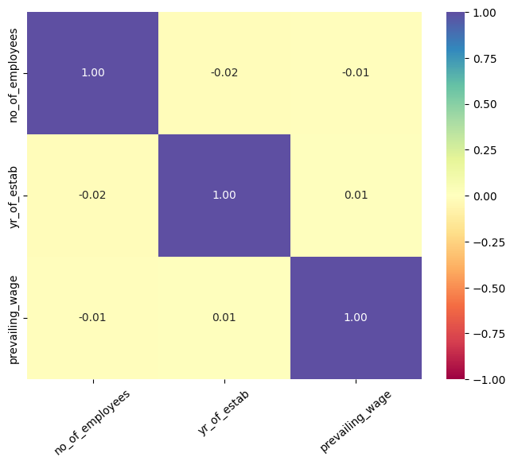

```python
# checking for correlation amomg variables
numeric_columns =X.select_dtypes(include=np.number).columns.tolist()
plt.figure(figsize=(8,6))
sns.heatmap(X[numeric_columns].corr(), annot=True, vmin=-1, vmax=1, fmt =".2f", cmap="Spectral")
plt.xticks(rotation=40);
plt.show()
```

```python
X.info()
```

```
<class 'pandas.core.frame.DataFrame'>
RangeIndex: 25480 entries, 0 to 25479
Data columns (total 21 columns):
 #   Column                             Non-Null Count  Dtype
---  ------                             --------------  -----
 0   no_of_employees                    25480 non-null  int64
 1   yr_of_estab                        25480 non-null  int64
 2   prevailing_wage                    25480 non-null  float64
 3   continent_Asia                     25480 non-null  bool
 4   continent_Europe                   25480 non-null  bool
 5   continent_North America            25480 non-null  bool
 6   continent_Oceania                  25480 non-null  bool
 7   continent_South America            25480 non-null  bool
 8   education_of_employee_Doctorate    25480 non-null  bool
 9   education_of_employee_High School  25480 non-null  bool
 10  education_of_employee_Master's     25480 non-null  bool
 11  has_job_experience_Y               25480 non-null  bool
 12  requires_job_training_Y            25480 non-null  bool
 13  region_of_employment_Midwest       25480 non-null  bool
 14  region_of_employment_Northeast     25480 non-null  bool
 15  region_of_employment_South         25480 non-null  bool
 16  region_of_employment_West          25480 non-null  bool
 17  unit_of_wage_Month                 25480 non-null  bool
 18  unit_of_wage_Week                  25480 non-null  bool
 19  unit_of_wage_Year                  25480 non-null  bool
 20  full_time_position_Y               25480 non-null  bool
dtypes: bool(18), float64(1), int64(2)
memory usage: 1.0 MB
```

- Most of the jobs are full-time rather than part-time. This attribute was not found to have an impact in the target (certification role).
- The higher the education level of an applicant, the more chances of visa certification.
- The majority do not require the employee to receive any job training. This attribute was not found to have an impact in this situation.
- Europe has the highest work visa certification rate at 79% approximately while the lowest work visa certification rate is for South America at 58% approximately.
- 89.4% of the applications are for full-time employment.
- No Linear correlation observed between numeric variables -> Almost 0 correlation

## Decision Tree - Model Building

```python
def confusion_matrix_sklearn(model, predictors, target):
    """
    To plot the confusion_matrix with percentages

    model: classifier
    predictors: independent variables
    target: dependent variable
    """
    y_pred = model.predict(predictors)
    cm = confusion_matrix(target, y_pred)
    labels = np.asarray(
        [
            ["{0:0.0f}".format(item) + "\n{0:.2%}".format(item / cm.flatten().sum())]
            for item in cm.flatten()
        ]
    ).reshape(2, 2)

    plt.figure(figsize=(6, 4))
    sns.heatmap(cm, annot=labels, fmt="")
    plt.ylabel("True label")
    plt.xlabel("Predicted label")
```

```python
# defining a function to compute different metrics to check performance of a classification model built using sklearn
def model_performance_classification_sklearn(model, predictors, target):
    """
    Function to compute different metrics to check classification model performance

    model: classifier
    predictors: independent variables
    target: dependent variable
    """

    # predicting using the independent variables
    pred = model.predict(predictors)

    acc = accuracy_score(target, pred)  # to compute Accuracy
    recall = recall_score(target, pred)  # to compute Recall
    precision = precision_score(target, pred)  # to compute Precision
    f1 = f1_score(target, pred)  # to compute F1-score

    # creating a dataframe of metrics
    df_perf = pd.DataFrame(
        {
            "Accuracy": acc,
            "Recall": recall,
            "Precision": precision,
            "F1": f1,
        },
        index=[0],
    )

    return df_perf
```

```python
dtree = DecisionTreeClassifier(criterion='gini',class_weight={0:0.17,1:0.83},random_state=1)
```

```python
dtree.fit(X_train, y_train)
```

```
DecisionTreeClassifier(class_weight={0: 0.17, 1: 0.83}, random_state=1)
```

```python
dtree_model_train_perf=model_performance_classification_sklearn(dtree, X_train, y_train)
print("Training performance \n",dtree_model_train_perf)
```

```
Training performance
    Accuracy  Recall  Precision   F1
0       1.0     1.0        1.0  1.0
```

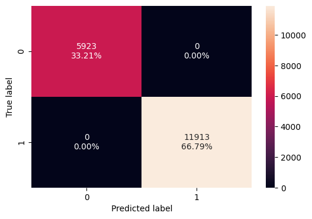

```python
confusion_matrix_sklearn(dtree, X_train, y_train)
```

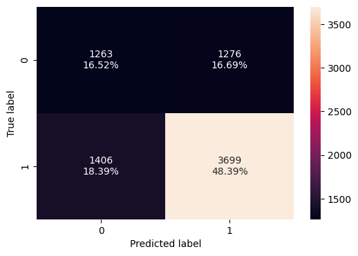

```python
confusion_matrix_sklearn(dtree, X_test, y_test)
```

```python
dtree_model_test_perf=model_performance_classification_sklearn(dtree, X_test, y_test)
print("Testing performance \n",dtree_model_test_perf)
```

```
Testing performance
    Accuracy    Recall  Precision        F1
0  0.649137  0.724584   0.743518  0.733929
```

```python
# choosing type of classifier
tuning_decision_tree =DecisionTreeClassifier(random_state=1)

# form grid of parameters to search in
grid_para ={
    "class_weight": ["balanced", None],
    "max_depth": np.arange(2, 20, 2),
    "max_leaf_nodes": np.arange(2, 20, 2),
    "min_samples_split": [50, 100, 150, 200],
    "min_impurity_decrease": [0.0001, 0.001, 0.01],
}

# setting type of score used to evaluate performance search
scorer = make_scorer(f1_score)

# running GridSearch
grid_obj =GridSearchCV(tuning_decision_tree, grid_para, scoring=scorer, cv =5)
grid_obj =grid_obj.fit(X_train, y_train)

# setting classifer to best combination of parameters
tuning_decision_tree =grid_obj.best_estimator_

# fitting best decision tree to training data
tuning_decision_tree.fit(X_train, y_train)
```

```
DecisionTreeClassifier(max_depth=np.int64(4), max_leaf_nodes=np.int64(14),
                       min_impurity_decrease=0.0001, min_samples_split=50,
                       random_state=1)
```

```python
dtree_tuning_model_train_perf=model_performance_classification_sklearn(tuning_decision_tree, X_train, y_train)
print("Training performance \n",dtree_tuning_model_train_perf)
```

```
Training performance
    Accuracy    Recall  Precision        F1
0  0.737441  0.916814   0.747366  0.823463
```

```python
dtree_tuning_model_test_perf=model_performance_classification_sklearn(tuning_decision_tree, X_test, y_test)
print("Training performance \n",dtree_tuning_model_test_perf)
```

```
Training performance
    Accuracy    Recall  Precision        F1
0  0.728938  0.914985   0.740371  0.818469
```

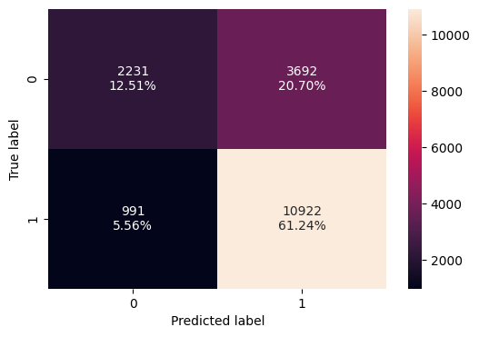

```python
confusion_matrix_sklearn(tuning_decision_tree, X_train, y_train)
```

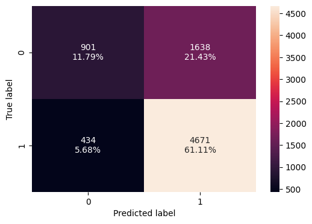

```python
confusion_matrix_sklearn(tuning_decision_tree, X_test, y_test)
```

## Bagging Model Building

```python
bagging = BaggingClassifier(random_state=1)
bagging.fit(X_train,y_train)
```

```
BaggingClassifier(random_state=1)
```

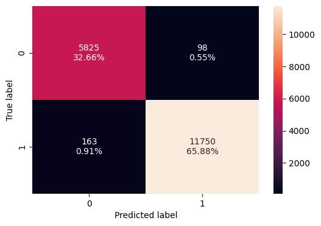

```python
confusion_matrix_sklearn(bagging, X_train, y_train)
```

```python
bagging.score(X_train,y_train)
```

```
0.9853666741421844
```

```python
bagging_model_train_perf=model_performance_classification_sklearn(bagging, X_train, y_train)
print("Training performance \n",bagging_model_train_perf)
```

```
Training performance
    Accuracy    Recall  Precision        F1
0  0.985367  0.986317   0.991729  0.989016
```

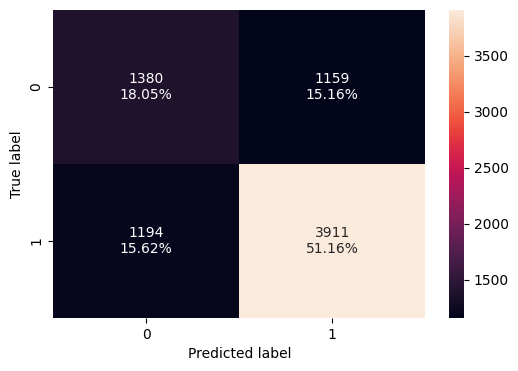

```python
confusion_matrix_sklearn(bagging, X_test, y_test)
```

```python
bagging_model_test_perf=model_performance_classification_sklearn(bagging, X_test, y_test)
print("Training performance \n",bagging_model_test_perf)
```

```
Training performance
    Accuracy    Recall  Precision        F1
0  0.692177  0.766112     0.7714  0.768747
```

```python
bagging.score(X_test, y_test)
```

```
0.6921768707482994
```

```python
bagging_wt = BaggingClassifier(estimator=DecisionTreeClassifier(criterion='gini',class_weight={0:0.17,1:0.83},random_state=1),random_state=1)
bagging_wt.fit(X_train,y_train)
```

```
BaggingClassifier(estimator=DecisionTreeClassifier(class_weight={0: 0.17,
                                                                 1: 0.83},
                                                   random_state=1),
                  random_state=1)
```

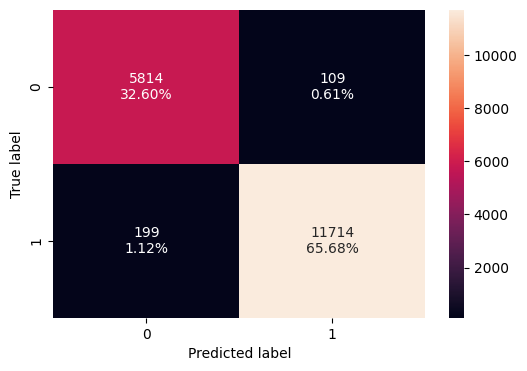

```python
confusion_matrix_sklearn(bagging_wt,X_train,y_train)
```

```python
bagging_wt.score(X_train,y_train)
```

```
0.9827315541601256
```

```python
bagging_wt_model_train_perf=model_performance_classification_sklearn(bagging_wt,X_train,y_train)
print("Training performance \n",bagging_wt_model_train_perf)
```

```
Training performance
    Accuracy    Recall  Precision        F1
0  0.982732  0.983296   0.990781  0.987024
```

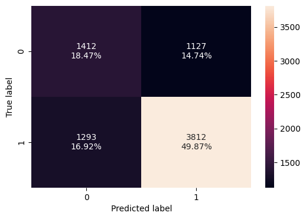

```python
confusion_matrix_sklearn(bagging_wt,X_test,y_test)
```

```python
bagging_wt_model_test_perf=model_performance_classification_sklearn(bagging_wt, X_test, y_test)
print("Testing performance \n",bagging_wt_model_test_perf)
```

```
Testing performance
    Accuracy    Recall  Precision       F1
0  0.683412  0.746719   0.771816  0.75906
```

```python
bagging_wt.score(X_test, y_test)
```

```
0.6834118262689691
```

```python
rf = RandomForestClassifier(random_state=1)
rf.fit(X_train,y_train)
```

```
RandomForestClassifier(random_state=1)
```

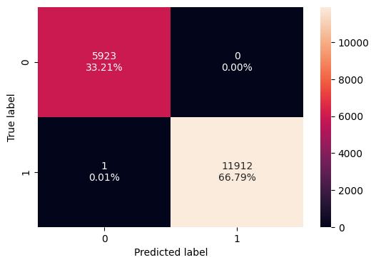

```python
confusion_matrix_sklearn(rf,X_train,y_train)
```

```python
rf.score(X_train,y_train)
```

```
0.999943933617403
```

```python
rf_model_train_perf=model_performance_classification_sklearn(rf,X_train,y_train)
print("Training performance \n",rf_model_train_perf)
```

```
Training performance
    Accuracy    Recall  Precision        F1
0  0.999944  0.999916        1.0  0.999958
```

```python
rf.score(X_test,y_test)
```

```
0.7191261119832548
```

```python
rf_model_test_perf=model_performance_classification_sklearn(rf,X_test,y_test)
print("Testing performance \n",rf_model_test_perf)
```

```
Testing performance
    Accuracy    Recall  Precision        F1
0  0.719126  0.830167   0.768032  0.797891
```

- Random Forest is overfitting badly on the train set.

```python
rf_wt = RandomForestClassifier(class_weight={0:0.17,1:0.83}, random_state=1)
rf_wt.fit(X_train,y_train)
```

```
RandomForestClassifier(class_weight={0: 0.17, 1: 0.83}, random_state=1)
```

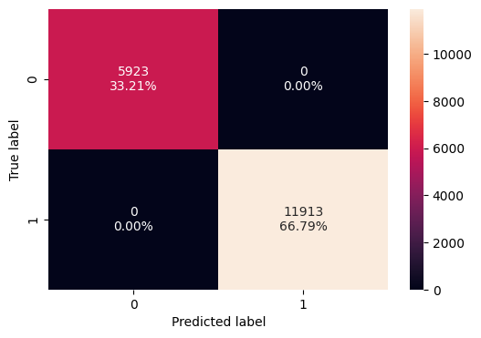

```python
confusion_matrix_sklearn(rf_wt, X_train,y_train)
```

```python
rf_wt_model_train_perf=model_performance_classification_sklearn(rf_wt, X_train,y_train)
print("Training performance \n",rf_wt_model_train_perf)
```

```
Training performance
    Accuracy  Recall  Precision   F1
0       1.0     1.0        1.0  1.0
```

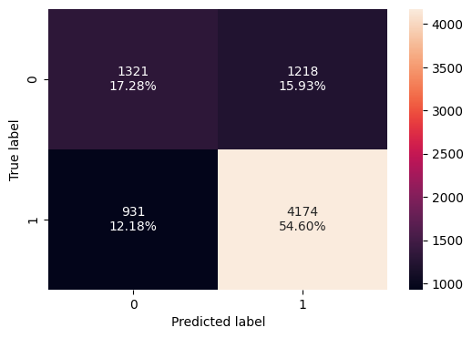

```python
confusion_matrix_sklearn(rf_wt, X_test,y_test)
```

```python
rf_wt_model_test_perf=model_performance_classification_sklearn(rf_wt, X_test,y_test)
print("Testing performance \n",rf_wt_model_test_perf)
```

```
Testing performance
    Accuracy   Recall  Precision        F1
0  0.718864  0.81763    0.77411  0.795275
```

- There is not much improvement in metrics of weighted random forest as compared to the unweighted random forest.
- Bagging classifier with a weighted decision tree is not able to generalize well on the data.
- Decision tree model performs well for the training data set and all performance metrics, i.e., accuracy, recall, precision, and F1-score are approx 1.00.
- However, on the test set performance is not that good (F1-score is 0.75 approximately) indicating the model is overfitting.

## Boosting Model Building

```python
adaboost_clf = AdaBoostClassifier(n_estimators=50)
#abcl = AdaBoostClassifier(n_estimators=50)
adaboost_clf = adaboost_clf.fit(X_train, y_train)
```

```python
ab_regressor_model_train = model_performance_classification_sklearn(adaboost_clf, X_train,y_train)
print("Training performance \n",ab_regressor_model_train)
```

```
Training performance
    Accuracy   Recall  Precision        F1
0  0.739684  0.88735   0.762039  0.819934
```

```python
ab_regressor_model_test_perf = model_performance_classification_sklearn(adaboost_clf, X_test,y_test)
print("Testing performance \n",ab_regressor_model_test_perf)
```

```
Testing performance
    Accuracy    Recall  Precision        F1
0  0.735348  0.884819   0.758905  0.817039
```

### Gradient Boost

```python
gbcl = GradientBoostingClassifier(n_estimators = 50, max_depth=5)
gbcl = gbcl.fit(X_train, y_train)
```

```python
gbcl_train = model_performance_classification_sklearn(gbcl, X_train,y_train)
print("Training performance \n",gbcl_train)
```

```
Training performance
    Accuracy    Recall  Precision        F1
0  0.768166  0.884076   0.792714  0.835906
```

```python
gbcl_test = model_performance_classification_sklearn(gbcl, X_test,y_test)
print("Testing performance \n",gbcl_test)
```

```
Testing performance
    Accuracy    Recall  Precision       F1
0  0.747253  0.869736   0.777992  0.82131
```

## Model Performance Comparison and Conclusions

```python
# training performance comparison

models_train_comp_df = pd.concat(
    [dtree_model_train_perf.T,dtree_tuning_model_train_perf.T,bagging_model_train_perf.T, bagging_wt_model_train_perf.T,rf_model_train_perf.T,
    rf_wt_model_train_perf.T, ab_regressor_model_train.T, gbcl_train.T],
    axis=1,
)
models_train_comp_df.columns = [
    "Decision Tree",
    "Decision Tuned Tree",
    "Bagging Classifier",
    "Weighted Bagging Classifier",
    "Random Forest Classifier",
    "Weighted Random Forest Classifier",
    "Adaboost Classifier",
    "Gradient Boost Classifier"
    ]
print("Training performance comparison:")
models_train_comp_df
```

```
Training performance comparison:
```

|  | Decision Tree | Decision Tuned Tree | Bagging Classifier | Weighted Bagging Classifier | Random Forest Classifier | Weighted Random Forest Classifier | Adaboost Classifier | Gradient Boost Classifier |
| --- | --- | --- | --- | --- | --- | --- | --- | --- |
| Accuracy | 1.0 | 0.737441 | 0.985367 | 0.982732 | 0.999944 | 1.0 | 0.739684 | 0.768166 |
| Recall | 1.0 | 0.916814 | 0.986317 | 0.983296 | 0.999916 | 1.0 | 0.887350 | 0.884076 |
| Precision | 1.0 | 0.747366 | 0.991729 | 0.990781 | 1.000000 | 1.0 | 0.762039 | 0.792714 |
| F1 | 1.0 | 0.823463 | 0.989016 | 0.987024 | 0.999958 | 1.0 | 0.819934 | 0.835906 |

```python
# training performance comparison

models_test_comp_df = pd.concat(
    [dtree_model_test_perf.T,dtree_tuning_model_test_perf.T,bagging_model_test_perf.T, bagging_wt_model_test_perf.T,rf_model_test_perf.T,
    rf_wt_model_test_perf.T, ab_regressor_model_test_perf.T, gbcl_test.T],
    axis=1,
)
models_test_comp_df.columns = [
    "Decision Tree",
    "Decision Tuned Tree",
    "Bagging Classifier",
    "Weighted Bagging Classifier",
    "Random Forest Classifier",
    "Weighted Random Forest Classifier",
    "Adaboost Classifier",
    "Gradient Boost Classifier"
    ]
print("Testing performance comparison:")
models_test_comp_df
```

```
Testing performance comparison:
```

|  | Decision Tree | Decision Tuned Tree | Bagging Classifier | Weighted Bagging Classifier | Random Forest Classifier | Weighted Random Forest Classifier | Adaboost Classifier | Gradient Boost Classifier |
| --- | --- | --- | --- | --- | --- | --- | --- | --- |
| Accuracy | 0.649137 | 0.728938 | 0.692177 | 0.683412 | 0.719126 | 0.718864 | 0.735348 | 0.747253 |
| Recall | 0.724584 | 0.914985 | 0.766112 | 0.746719 | 0.830167 | 0.817630 | 0.884819 | 0.869736 |
| Precision | 0.743518 | 0.740371 | 0.771400 | 0.771816 | 0.768032 | 0.774110 | 0.758905 | 0.777992 |
| F1 | 0.733929 | 0.818469 | 0.768747 | 0.759060 | 0.797891 | 0.795275 | 0.817039 | 0.821310 |

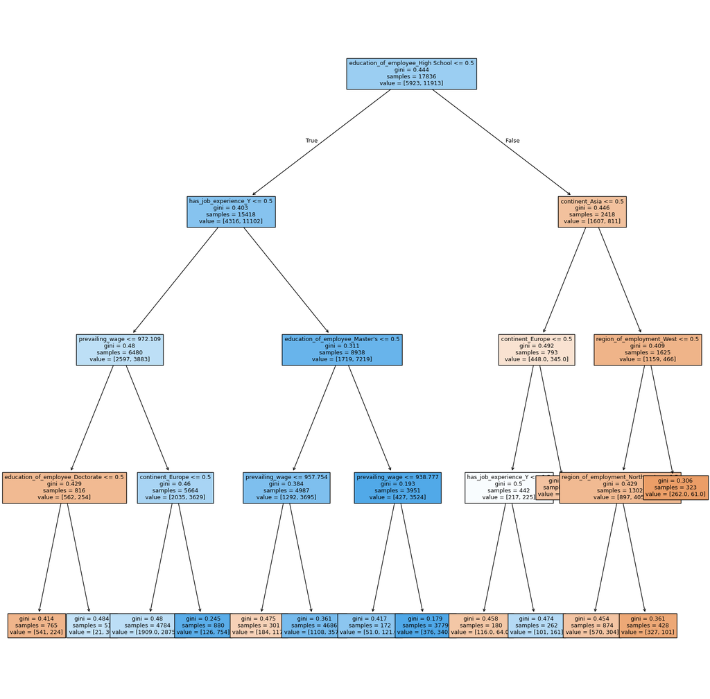

```python
# list of feature names in X_train
feature_names = list(X_train.columns)

# set the figure size for the plot
plt.figure(figsize=(20, 20))

# plotting the decision tree
out = tree.plot_tree(
    tuning_decision_tree,                         # decision tree classifier model
    feature_names=feature_names,    # list of feature names (columns) in the dataset
    filled=True,                    # fill the nodes with colors based on class
    fontsize=9,                     # font size for the node text
    node_ids=False,                 # do not show the ID of each node
    class_names=None,               # whether or not to display class names
)

# add arrows to the decision tree splits if they are missing
for o in out:
    arrow = o.arrow_patch
    if arrow is not None:
        arrow.set_edgecolor("black")    # set arrow color to black
        arrow.set_linewidth(1)          # set arrow linewidth to 1

# displaying the plot
plt.show()
```

```python
# printing a text report showing the rules of a decision tree
print(
    tree.export_text(
        tuning_decision_tree,    # specify the model
        feature_names=feature_names,    # specify the feature names
        show_weights=True    # specify whether or not to show the weights associated with the model
    )
)
```

```
|--- education_of_employee_High School <= 0.50
|   |--- has_job_experience_Y <= 0.50
|   |   |--- prevailing_wage <= 972.11
|   |   |   |--- education_of_employee_Doctorate <= 0.50
|   |   |   |   |--- weights: [541.00, 224.00] class: 0
|   |   |   |--- education_of_employee_Doctorate >  0.50
|   |   |   |   |--- weights: [21.00, 30.00] class: 1
|   |   |--- prevailing_wage >  972.11
|   |   |   |--- continent_Europe <= 0.50
|   |   |   |   |--- weights: [1909.00, 2875.00] class: 1
|   |   |   |--- continent_Europe >  0.50
|   |   |   |   |--- weights: [126.00, 754.00] class: 1
|   |--- has_job_experience_Y >  0.50
|   |   |--- education_of_employee_Master's <= 0.50
|   |   |   |--- prevailing_wage <= 957.75
|   |   |   |   |--- weights: [184.00, 117.00] class: 0
|   |   |   |--- prevailing_wage >  957.75
|   |   |   |   |--- weights: [1108.00, 3578.00] class: 1
|   |   |--- education_of_employee_Master's >  0.50
|   |   |   |--- prevailing_wage <= 938.78
|   |   |   |   |--- weights: [51.00, 121.00] class: 1
|   |   |   |--- prevailing_wage >  938.78
|   |   |   |   |--- weights: [376.00, 3403.00] class: 1
|--- education_of_employee_High School >  0.50
|   |--- continent_Asia <= 0.50
|   |   |--- continent_Europe <= 0.50
|   |   |   |--- has_job_experience_Y <= 0.50
|   |   |   |   |--- weights: [116.00, 64.00] class: 0
|   |   |   |--- has_job_experience_Y >  0.50
|   |   |   |   |--- weights: [101.00, 161.00] class: 1
|   |   |--- continent_Europe >  0.50
|   |   |   |--- weights: [231.00, 120.00] class: 0
|   |--- continent_Asia >  0.50
|   |   |--- region_of_employment_West <= 0.50
|   |   |   |--- region_of_employment_Northeast <= 0.50
|   |   |   |   |--- weights: [570.00, 304.00] class: 0
|   |   |   |--- region_of_employment_Northeast >  0.50
|   |   |   |   |--- weights: [327.00, 101.00] class: 0
|   |   |--- region_of_employment_West >  0.50
|   |   |   |--- weights: [262.00, 61.00] class: 0
```

### Feature importance

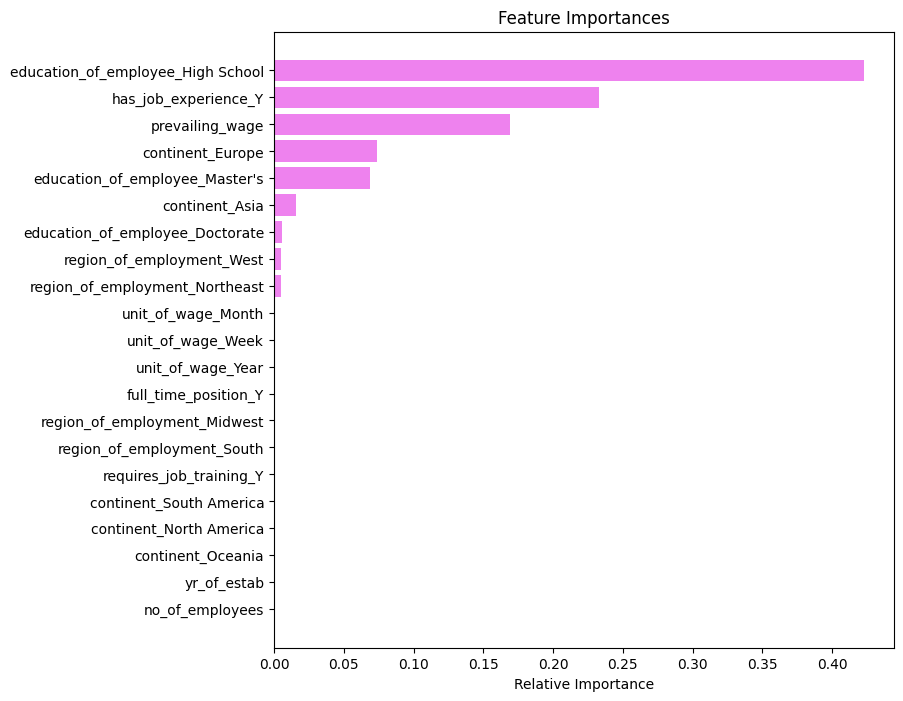

```python
# importance of features in the tree building
importances = tuning_decision_tree.feature_importances_
indices = np.argsort(importances)

plt.figure(figsize=(8, 8))
plt.title("Feature Importances")
plt.barh(range(len(indices)), importances[indices], color="violet", align="center")
plt.yticks(range(len(indices)), [feature_names[i] for i in indices])
plt.xlabel("Relative Importance")
plt.show()
```

- Applicant having prior job experience, and has completed studies plays important role in getting visa application certified